# Quentin K-Means questions

We have an R object named `xynames`.

`r`r load(‘xynames.RData’)

Within the data structure `xynames` are three lists that contain all the data needed to create a plot.

`r`r names(xynames) <- c(‘x’,‘y’,‘name’) summary(xynames)

```
     Length Class  Mode
x    412    -none- numeric
y    412    -none- numeric
name 412    -none- character
```

[output not shown]

We can plot them abd see what the plot looks like.

`r`r coords.x <- unlist(xynames[1]) coords.y <- unlist(xynames[2]) coords.names <- unlist(xynames[3]) plot( x = coords.x, y = coords.y )

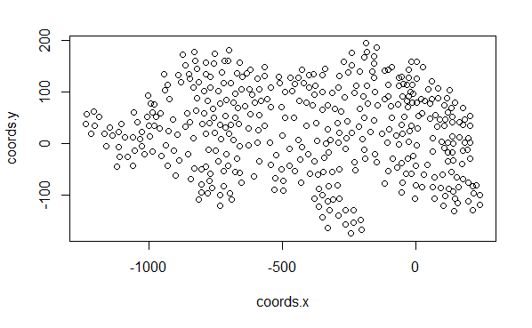

We want to try out the `kmeans` method in base R, so we create a data structure that `kmeans` accepts.

`r`r coords.matrix <- rbind( matrix(coords.x,ncol=2), matrix(coords.y,ncol=2) ) colnames(coords.matrix) <- c(‘x’,‘y’) rownames(coords.matrix) <- coords.names print(head(coords.matrix,n=10L))

```
              x      y
gneJ10    85.58 -66.85
gneJ100 -261.90 -89.19
gneJ101 -289.27 -43.50
gneJ103 -291.37   9.16
gneJ104 -284.35 -16.14
gneJ106 -144.73  63.86
gneJ107 -224.71  98.85
gneJ109 -286.43 -32.76
gneJ11   129.67 137.79
gneJ110   -8.00 165.73
```

`r`r newone <- cbind(coords.x, coords.y)

`r`r plot(newone)

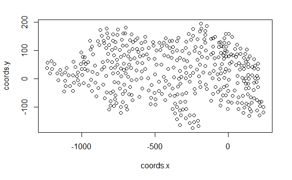

And then we run them through the `kmeans` method.

`r`r ncenters <- 7 coords.clusters <- kmeans( x = newone, centers = ncenters, iter.max = 50, nstart = 27, algorithm = ‘Hartigan-Wong’ ) print(coords.clusters)

```
K-means clustering with 7 clusters of sizes 49, 69, 56, 46, 65, 87, 40

Cluster means:
     coords.x  coords.y
1 -1042.40837  26.24510
2   -34.14159  50.53899
3  -520.03054  50.05089
4  -241.13261  98.18174
5   142.12446 -23.33108
6  -760.21517  41.60632
7  -311.07200 -76.30950

Clustering vector:
  x1   x2   x3   x4   x5   x6   x7   x8   x9  x10  x11  x12  x13  x14  x15  x16  x17
   2    7    7    7    7    2    7    7    5    2    2    2    5    2    5    5    5
 x18  x19  x20  x21  x22  x23  x24  x25  x26  x27  x28  x29  x30  x31  x32  x33  x34
   5    5    5    5    5    5    5    5    5    5    5    5    5    5    5    5    5
 x35  x36  x37  x38  x39  x40  x41  x42  x43  x44  x45  x46  x47  x48  x49  x50  x51
   5    5    5    4    3    3    6    3    3    3    3    6    3    3    3    3    3
 x52  x53  x54  x55  x56  x57  x58  x59  x60  x61  x62  x63  x64  x65  x66  x67  x68
   7    5    7    7    3    5    3    3    6    6    6    3    3    6    6    5    5
 x69  x70  x71  x72  x73  x74  x75  x76  x77  x78  x79  x80  x81  x82  x83  x84  x85
   6    6    6    6    6    6    6    6    5    6    6    6    6    6    1    1    1
 x86  x87  x88  x89  x90  x91  x92  x93  x94  x95  x96  x97  x98  x99 x100 x101 x102
   5    1    1    1    1    1    1    1    1    5    1    1    1    1    1    1    1
x103 x104 x105 x106 x107 x108 x109 x110 x111 x112 x113 x114 x115 x116 x117 x118 x119
   1    6    5    6    6    1    1    1    1    1    5    1    1    1    1    6    6
x120 x121 x122 x123 x124 x125 x126 x127 x128 x129 x130 x131 x132 x133 x134 x135 x136
   5    6    5    6    6    6    7    5    7    7    7    7    7    5    5    7    7
x137 x138 x139 x140 x141 x142 x143 x144 x145 x146 x147 x148 x149 x150 x151 x152 x153
   7    7    5    5    5    2    7    7    7    7    7    7    7    2    7    7    7
x154 x155 x156 x157 x158 x159 x160 x161 x162 x163 x164 x165 x166 x167 x168 x169 x170
   7    7    7    7    7    7    4    4    4    4    4    4    4    3    4    4    4
x171 x172 x173 x174 x175 x176 x177 x178 x179 x180 x181 x182 x183 x184 x185 x186 x187
   2    4    4    4    4    4    2    2    4    4    2    4    4    4    4    4    4
x188 x189 x190 x191 x192 x193 x194 x195 x196 x197 x198 x199 x200 x201 x202 x203 x204
   4    4    4    4    2    4    4    4    4    5    5    2    2    2    2    2    2
x205 x206 x207 x208 x209 x210 x211 x212 x213 x214 x215 x216 x217 x218 x219 x220 x221
   2    2    2    2    2    2    2    5    5    2    5    5    5    7    7    2    2
x222 x223 x224 x225 x226 x227 x228 x229 x230 x231 x232 x233 x234 x235 x236 x237 x238
```

[output cut: 17 more lines]

```
x375 x376 x377 x378 x379 x380 x381 x382 x383 x384 x385 x386 x387 x388 x389 x390 x391
   6    1    1    2    2    5    5    2    2    5    5    5    2    2    4    2    2
x392 x393 x394 x395 x396 x397 x398 x399 x400 x401 x402 x403 x404 x405 x406 x407 x408
   2    2    2    2    5    4    4    4    4    4    4    2    2    4    5    4    4
x409 x410 x411 x412
   3    3    7    4

Within cluster sum of squares by cluster:
[1]  543155.6  552337.8  570482.9  356394.1  443713.6 1034288.4  279995.4
 (between_SS / total_SS =  94.3 %)

Available components:

[1] \cluster\      \centers\      \totss\        \withinss\     \tot.withinss\
[6] \betweenss\    \size\         \iter\         \ifault\
```

We can view our clusters with a plot.

`r`r plot(x = newone, col = coords.clusters$cluster) points(coords.clusters$centers, col = 1:ncenters , pch = 8, cex = 2)

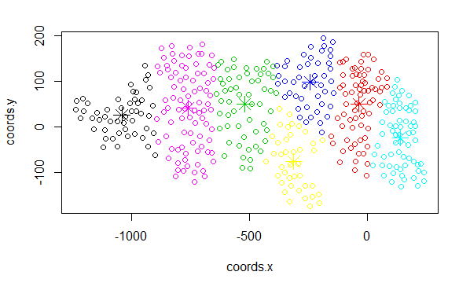

`r`r library(tidyverse)

`r`r quentin <- as.data.frame(coords.matrix)

`r`r cop_data <- as.data.frame(newone)

[figure not shown]

I can see that my junctions (points) are being clustered when I plot my points color coded to the clusters they belong with.

`r`r plot( x = coords.x, y = coords.y, col = coords.clusters$cluster ) points(coords.clusters$centers, col = 1:ncenters , pch = 8, cex = 2)

[figure not shown]